# Biological Interpretation of NMF components

This is the fun part. We’ve optimized these highly abstracted gene sets, now we figure out what the heck we’ve isolated. This is another spot where our tumour-informed optimization outperforms the biologically informed approach: we have made very few assumptions about cell-types to get here, so our biological interpretation should not be (as) biased.

## Data intake

Start by normalizing the W and H matrices for interpretation

```r
suppressWarnings(
suppressPackageStartupMessages({

  library(data.table)
  library(dplyr)
  library(tidyr)
  library(stringr)
  library(tibble)
  library(reshape2)
  library(pvclust)
  library(msigdbr)
  library(gprofiler2)
  library(org.Hs.eg.db)
  library(clusterProfiler)
  library(enrichplot)
  library(cowplot)
  library(ggplot2)
  library(PNWColors)

})
)

packageVersion('clusterProfiler')
```

```
## [1] '4.16.0'
```

```r
code.dir = '~/Documents/scripts/github/btc-ccs/'
data.dir = '~/Documents/scripts/github/btc-ccs-data/'
source( file.path(data.dir, "paths.R"))
cluster.dir = file.path(cluster.dir, 'nmf_analysis')

source( file.path(code.dir, "bin/BTC.functions.R"))
source( file.path(code.dir, "bin/nmf.functions.R"))

base_font_size = 10
x_top_angle = 50

gene_set <- fread(file.path(data.dir,'/source_data/fgs.txt'))
gene_set$kb <- gene_set$Length / 1000

gene_vec <- gene_set$ensid
names(gene_vec) <- gene_set$gene_name
gene_kb <- gene_set$kb
names(gene_kb) <- gene_set$ensid

cohorts <- c('whole','naive','icca','primary')
this.cohort = cohorts[1]

nmf.stats <- fread(file.path(data.dir,'results',paste0(this.cohort,'.nmf.stats.txt')))

nmf.stats <- nmf.stats %>%
  filter(top == 1)

component_n = unique(nmf.stats$k)
gene_n = unique(nmf.stats$genes)

nmf.stats %>%
  filter(k == component_n & genes == gene_n & cor > 0.2) %>%
  dplyr::select(genes, sig.id, cor, cor.p) %>%
  arrange(cor.p)
```

```
##    genes sig.id       cor        cor.p
##    <int> <char>     <num>        <num>
## 1:  6000   sig7 0.4934762 0.0001496656
## 2:  6000   sig3 0.4449864 0.0024733634
```

```r
over.write.matrices = T
if(over.write.matrices){
    save.nmf.matrices(component_n, gene_n,
                      cluster.dir = file.path(cluster.dir, this.cohort), data.dir=data.dir,
                      cohort=this.cohort)
}

## pull from results/
W_matrix <- read.csv(file.path(data.dir,'results',paste0(this.cohort,'.W_matrix.txt')), row.names= 1)
H_matrix <- read.csv(file.path(data.dir,'results',paste0(this.cohort,'.H_matrix.txt')), row.names = 1)

rownames(W_matrix) <- gene_vec[rownames(W_matrix)]
tpm_data <- reformat_w_matrix(W_matrix, gene_kb)

H_matrix_ordered_norm.melt <- reformat_h_matrix(H_matrix)
```

## Correlations between components

How often do our signatures show up together (or tend to be exclusive)? Since the “names” of the signatures until now are arbitrary, we rename the signatures here such that correlated signatures are closer numerically. That’s how we end up with the two CCS-B signatures close numerically, and this also results in a numerical distance between CCS-A and CCS-B signatures.

```r
# Compute pairwise correlations between rows
H_matrix_ordered_norm <-   data.frame(t(apply(H_matrix, 1, scale)))
names(H_matrix_ordered_norm) <- names(H_matrix)
cor_matrix <- cor(t(H_matrix_ordered_norm) )

pvclust.result <- pvclust(t(cor_matrix), method.hclust = 'complete' )
```

```
## Bootstrap (r = 0.5)... Done.
```

```
## Bootstrap (r = 0.62)... Done.
## Bootstrap (r = 0.75)... Done.
## Bootstrap (r = 0.88)... Done.
## Bootstrap (r = 1.0)... Done.
## Bootstrap (r = 1.12)... Done.
## Bootstrap (r = 1.25)... Done.
## Bootstrap (r = 1.38)... Done.
```

```r
order_vec <- rev(pvclust.result$hclust$labels[pvclust.result$hclust$order])
y_order <- rev(paste0('sig',rev(pvclust.result$hclust$labels[pvclust.result$hclust$order])))

y_order.convert <- cbind.data.frame('og'=y_order, 'new'=paste0('sig.',c(length(y_order):1)))
y_order.convert$new <- factor(y_order.convert$new, levels = paste0('sig.',c(length(y_order):1)))

if(over.write.matrices){
  write.table( y_order.convert,
               file = file.path(data.dir,'results',paste0(this.cohort,'.NMF.conversion.txt')),
               row.names = F,col.names = T, quote = FALSE, sep = "\t", append =F)
}

full_correlation_matrix(H_matrix_ordered_norm, order_vec, component_n)
```

```
##    sig.id variable      value cor.bin
## 1    sig1     sig4 -0.2676542    down
## 2    sig2     sig4 -0.2285193    down
## 3    sig2     sig3 -0.2317885    down
## 4    sig3     <NA>         NA    <NA>
## 5    sig4     sig3  0.1970766      up
## 6    sig5     <NA>         NA    <NA>
## 7    sig6     sig5 -0.2255226    down
## 8    sig6     sig4 -0.2512107    down
## 9    sig6     sig8 -0.2455028    down
## 10   sig7     sig1  0.2294452      up
## 11   sig7     sig5 -0.3021402    down
## 12   sig7     sig4 -0.6081092    down
## 13   sig7     sig3 -0.4900704    down
## 14   sig7     sig8 -0.1843253    down
## 15   sig8     <NA>         NA    <NA>
```

```r
y_order.convert
```

```
##     og   new
## 1 sig8 sig.8
## 2 sig3 sig.7
## 3 sig4 sig.6
## 4 sig2 sig.5
## 5 sig5 sig.4
## 6 sig6 sig.3
## 7 sig1 sig.2
## 8 sig7 sig.1
```

## CCS markers from TSP

So far we’ve used well defined signals (known signatures) to identify our components. Next, we use the genes from the TSP defining our CCS.

```r
cms.gsea.full <- get_ccs_enrichment(W_matrix, data.dir, component_n, y_order.convert)
```

```
## --
##
##  1
```

```
## using 'fgsea' for GSEA analysis, please cite Korotkevich et al (2019).
```

```
## preparing geneSet collections...
```

```
## GSEA analysis...
```

```
## leading edge analysis...
```

```
## done...
```

```
## --
##
##  2
```

```
## using 'fgsea' for GSEA analysis, please cite Korotkevich et al (2019).
```

```
## preparing geneSet collections...
```

```
## GSEA analysis...
```

```
## leading edge analysis...
```

```
## done...
```

```
## --
##
##  3
```

```
## using 'fgsea' for GSEA analysis, please cite Korotkevich et al (2019).
```

```
## preparing geneSet collections...
```

```
## GSEA analysis...
```

```
## leading edge analysis...
```

```
## done...
```

```
## --
##
##  4
```

```
## using 'fgsea' for GSEA analysis, please cite Korotkevich et al (2019).
```

```
## preparing geneSet collections...
```

```
## GSEA analysis...
```

```
## leading edge analysis...
```

```
## done...
```

```
## --
##
##  5
```

```
## using 'fgsea' for GSEA analysis, please cite Korotkevich et al (2019).
```

```
## preparing geneSet collections...
```

```
## GSEA analysis...
```

```
## leading edge analysis...
```

```
## done...
```

```
## --
##
##  6
```

```
## using 'fgsea' for GSEA analysis, please cite Korotkevich et al (2019).
```

```
## preparing geneSet collections...
```

```
## GSEA analysis...
```

```
## leading edge analysis...
```

```
## done...
```

```
## --
##
##  7
```

```
## using 'fgsea' for GSEA analysis, please cite Korotkevich et al (2019).
```

```
## preparing geneSet collections...
```

```
## GSEA analysis...
```

```
## leading edge analysis...
```

```
## done...
```

```
## --
##
##  8
```

```
## using 'fgsea' for GSEA analysis, please cite Korotkevich et al (2019).
```

```
## preparing geneSet collections...
```

```
## GSEA analysis...
```

```
## leading edge analysis...
```

```
## done...
```

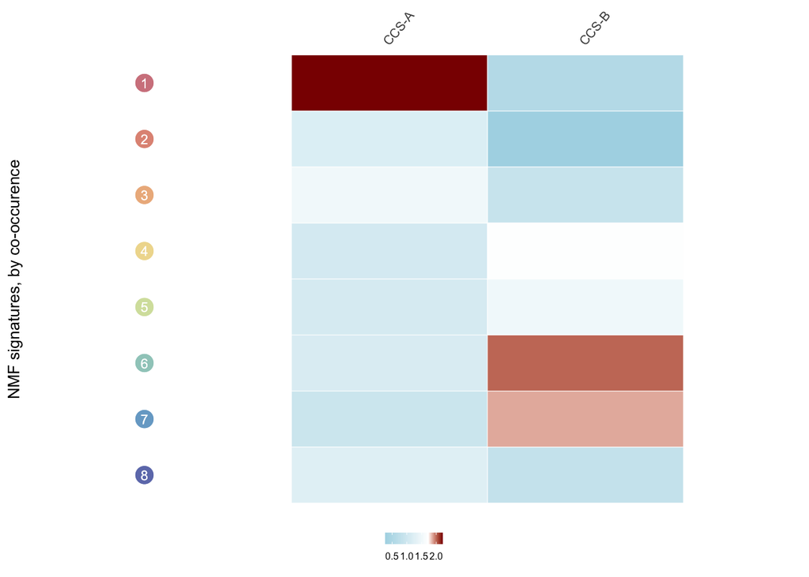

```r
label.df <- cms.gsea.full |>
  distinct(new, Description)

cms.plot <-
ggplot(cms.gsea.full, aes(x = Description, y = new)) +

  geom_tile(aes(fill = NES), color = "white") +

  geom_point(
    data = label.df,
    aes(x = -0.25, y = new, color = new),
    stroke = 4, shape = 21,   size = 0
  ) +

  geom_text(
    data = label.df,
    aes(x = -0.25, y = new, label = gsub('sig.','',new)),
    size = 3, color='white'
  ) +

  coord_cartesian(xlim = c(-0.25, 2.5), clip = "off") +
  theme_bw(base_size = base_font_size)+

  theme(
    axis.text.x = element_text(angle = x_top_angle, hjust = 0),
    panel.grid = element_blank(),
    axis.title.x = element_blank(),
    axis.ticks = element_blank(),
    panel.spacing = unit(0, "lines"),
    plot.background = element_blank(),
    panel.background = element_blank(),
    panel.border = element_blank(),
    strip.background = element_blank(),
    strip.text = element_text(color = "black"),
    legend.position = 'bottom',
    legend.background = element_blank(),
    legend.text = element_text(size = 6),
    legend.key.size = unit(0.5, "lines"),
    legend.title = element_blank(),
    axis.text.y = element_blank(),
    axis.ticks.y = element_blank(),
  )+ guides(color='none')+
  scale_color_manual(values = pnw_palette(name="Sailboat", n=component_n ))+
  scale_x_discrete(position = "top", na.translate = FALSE)+
  scale_fill_gradientn(
    colours = c("lightblue", "white", "darkred"),
    values = scales::rescale(c(0, 1.5, 2))
  ) + labs(y='NMF signatures, by co-occurence')

cms.plot
```

```r
cms.gsea.full %>% dplyr::select(new, Description, NES, p.adjust) %>% arrange(Description, desc(new))
```

```
##      new Description       NES     p.adjust
## 1  sig.1       CCS-A 2.2207002 2.179446e-09
## 2  sig.2       CCS-A 1.1889216 5.274725e-01
## 3  sig.3       CCS-A 1.5114897 3.935148e-02
## 4  sig.4       CCS-A 1.0665530 3.766234e-01
## 5  sig.5       CCS-A 1.1063764 3.126873e-01
## 6  sig.6       CCS-A 1.1433523 2.727273e-01
## 7  sig.7       CCS-A 0.9379403 5.794206e-01
## 8  sig.8       CCS-A 1.2308135 3.096903e-01
## 9  sig.1       CCS-B 0.5716730 9.840160e-01
## 10 sig.2       CCS-B 0.2624209 1.000000e+00
## 11 sig.3       CCS-B 0.8766738 7.072927e-01
## 12 sig.4       CCS-B 1.6963214 2.006508e-03
## 13 sig.5       CCS-B 1.4990394 4.776234e-02
## 14 sig.6       CCS-B 2.0082774 4.024162e-06
## 15 sig.7       CCS-B 1.8790054 1.771061e-04
## 16 sig.8       CCS-B 0.8205958 7.872128e-01
```

## external duct sets

Let’s augment our interpretation using biliary tract cell lineage markers identified by previous single-cell RNAseq studies of healthy tissue. We are going to use the data from [Sampaziotis et al 2021](https://pubmed.ncbi.nlm.nih.gov/33602855/), Rimland et al 2021, and [Andrews et al 2024](https://doi.org/10.1016/j.jhep.2023.12.023).

```r
duct.gene.set <- assemble_duct_markers(data.dir, gene_set)

chol.gsea.full <- test_duct_set(W_matrix, duct.gene.set, component_n)
```

```
## --
## 1
```

```
## using 'fgsea' for GSEA analysis, please cite Korotkevich et al (2019).
```

```
## preparing geneSet collections...
```

```
## GSEA analysis...
```

```
## leading edge analysis...
```

```
## done...
```

```
## --
## 2
```

```
## using 'fgsea' for GSEA analysis, please cite Korotkevich et al (2019).
```

```
## preparing geneSet collections...
```

```
## GSEA analysis...
```

```
## leading edge analysis...
```

```
## done...
```

```
## --
## 3
```

```
## using 'fgsea' for GSEA analysis, please cite Korotkevich et al (2019).
```

```
## preparing geneSet collections...
```

```
## GSEA analysis...
```

```
## leading edge analysis...
```

```
## done...
```

```
## --
## 4
```

```
## using 'fgsea' for GSEA analysis, please cite Korotkevich et al (2019).
```

```
## preparing geneSet collections...
```

```
## GSEA analysis...
```

```
## leading edge analysis...
```

```
## done...
```

```
## --
## 5
```

```
## using 'fgsea' for GSEA analysis, please cite Korotkevich et al (2019).
```

```
## preparing geneSet collections...
```

```
## GSEA analysis...
```

```
## leading edge analysis...
```

```
## done...
```

```
## --
## 6
```

```
## using 'fgsea' for GSEA analysis, please cite Korotkevich et al (2019).
```

```
## preparing geneSet collections...
```

```
## GSEA analysis...
```

```
## leading edge analysis...
```

```
## done...
```

```
## --
## 7
```

```
## using 'fgsea' for GSEA analysis, please cite Korotkevich et al (2019).
```

```
## preparing geneSet collections...
```

```
## GSEA analysis...
```

```
## leading edge analysis...
```

```
## done...
```

```
## --
## 8
```

```
## using 'fgsea' for GSEA analysis, please cite Korotkevich et al (2019).
```

```
## preparing geneSet collections...
```

```
## GSEA analysis...
```

```
## leading edge analysis...
```

```
## done...
```

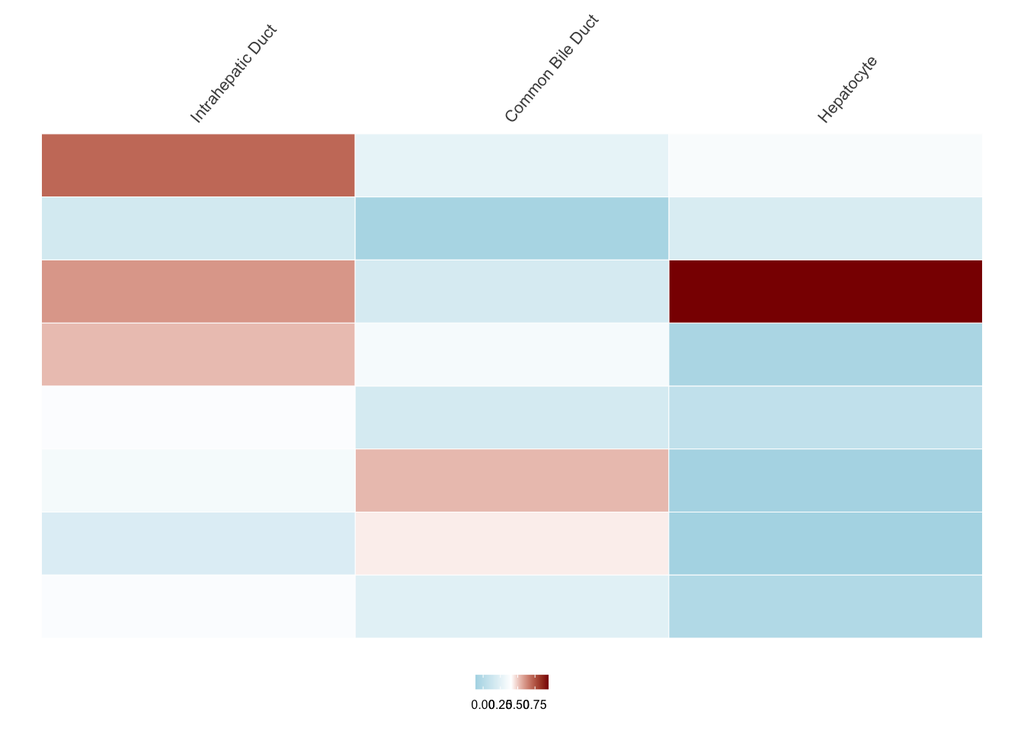

```r
chol.gsea.trim <- left_join(data.frame('sig.id'=paste0('sig',c(1:component_n))),
                            chol.gsea.full, by=c('sig.id'='sig.id')) %>%
   left_join(y_order.convert, by=c('sig.id'='og'))

## curate
chol.gsea.trim$cell <- NA
chol.gsea.trim$cell[chol.gsea.trim$Description == 'P-Hepato2'] <- 'Hepatocyte'
chol.gsea.trim$cell[chol.gsea.trim$Description == 'sampaziotis.IHD'] <- 'Intrahepatic Duct'
chol.gsea.trim$cell[chol.gsea.trim$Description == 'sampaziotis.CBD'] <- 'Common Bile Duct'
chol.gsea.hits <- chol.gsea.trim[!is.na(chol.gsea.trim$cell),]

chol.gsea.hits <- sort_celltypes(chol.gsea.hits)

scrna.match.plot <-
ggplot(chol.gsea.hits, aes(x=cell.f, y=new)) +

  geom_tile(aes(fill=log(NES)), color = "white") +

  theme_bw(base_size = base_font_size)+

  theme(axis.text.x = element_text(angle = x_top_angle, hjust = 0),
        panel.grid = element_blank(),
        axis.title = element_blank(),
        axis.ticks = element_blank(),
        axis.text.y = element_blank(),
        panel.spacing = unit(0, "lines"),
        plot.background = element_blank(),
        panel.background = element_blank(),
        panel.border = element_blank(),
        strip.background = element_blank(),
        strip.text = element_text(color = "black"),
        legend.position = 'bottom',
        legend.background = element_blank(),
        legend.text = element_text(size = 6),
        legend.key.size = unit(0.5, "lines"),
        legend.title = element_blank()) +

  guides(color = guide_legend(nrow = 3))+
  scale_x_discrete(position = "top", na.translate = FALSE)+
    scale_fill_gradient2(
      low = "lightblue",
      mid = "white",
      high = "darkred",
      midpoint = log(1.5), na.value = "darkblue"
    )

scrna.match.plot
```

```r
unique_sc_celltypes <- length(unique(chol.gsea.hits$cell.f))
chol.gsea.hits %>% dplyr::select(new, cell.f, NES, p.adjust) %>% arrange(desc(new))
```

```
##      new            cell.f       NES     p.adjust
## 1  sig.1 Intrahepatic Duct 2.0259948 6.750000e-10
## 2  sig.1  Common Bile Duct 1.3071592 1.472126e-04
## 3  sig.1        Hepatocyte 1.4374489 9.087897e-04
## 4  sig.2 Intrahepatic Duct 1.1691844 4.207792e-01
## 5  sig.2        Hepatocyte 1.2139075 6.113886e-01
## 6  sig.2  Common Bile Duct 0.9212501 1.000000e+00
## 7  sig.3        Hepatocyte 2.5720594 5.400000e-10
## 8  sig.3 Intrahepatic Duct 1.8269149 5.400000e-10
## 9  sig.3  Common Bile Duct 1.1936889 1.660000e-02
## 10 sig.4 Intrahepatic Duct 1.7003693 1.350000e-09
## 11 sig.4  Common Bile Duct 1.4242928 2.119536e-05
## 12 sig.4        Hepatocyte 0.9346812 6.587643e-01
## 13 sig.5 Intrahepatic Duct 1.4666155 3.857143e-10
## 14 sig.5  Common Bile Duct 1.1905460 1.894378e-02
## 15 sig.5        Hepatocyte 1.0609692 3.618881e-01
## 16 sig.6  Common Bile Duct 1.7081234 1.350000e-09
## 17 sig.6 Intrahepatic Duct 1.4155756 7.614086e-08
## 18 sig.6        Hepatocyte 0.9011892 7.822178e-01
## 19 sig.7  Common Bile Duct 1.5488003 1.900645e-08
## 20 sig.7 Intrahepatic Duct 1.2256818 5.674338e-03
## 21 sig.7        Hepatocyte 0.8960495 7.842926e-01
## 22 sig.8 Intrahepatic Duct 1.4628935 4.946423e-10
## 23 sig.8  Common Bile Duct 1.2668178 3.759217e-03
## 24 sig.8        Hepatocyte 0.9735067 5.757704e-01
```

## Human Protein Archive

How do our markers compare to protein expression by tissue from the [Human Protein Atlas](https://www.proteinatlas.org/)?

```r
hpa.trim <- pull_tissue_match(nmf.stats, component_n)
```

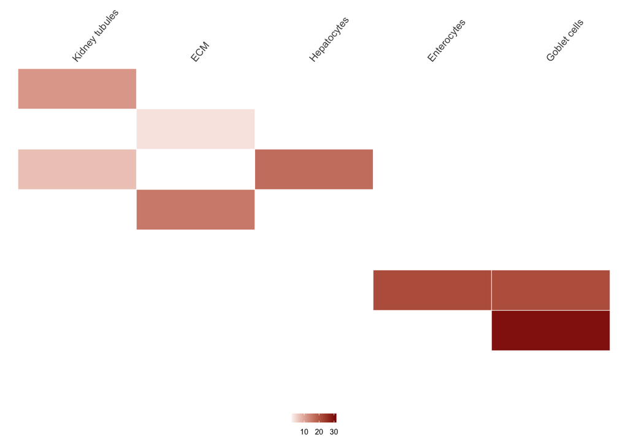

```r
hpa.trim <- left_join(hpa.trim, y_order.convert, by=c('sig.id'='og'))

## curate
hpa.trim$cell <- NA
hpa.trim$cell[hpa.trim$celltype == 'hepatocytes'] <- 'Hepatocytes'
hpa.trim$cell[hpa.trim$celltype == 'goblet cells'] <- 'Goblet cells'
hpa.trim$cell[hpa.trim$celltype == 'enterocytes '] <- 'Enterocytes'
hpa.trim$cell[hpa.trim$celltype %in% c('proximal tubules','proximal tubules (microvilli)')] <- 'Kidney tubules'
hpa.trim$cell[hpa.trim$celltype %in% c('extracellular matrix')] <- 'ECM'

hpa.hits <- sort_celltypes(hpa.trim)

hpa.grid <- expand.grid(x = levels(hpa.hits$cell.f), y = levels(hpa.hits$new))

hpa.match.plot <-
ggplot(hpa.hits, aes(x=cell.f, y=new)) +

  geom_tile(data = hpa.grid, aes(x = x, y = y), fill = "white", color = "white") +
  geom_tile(aes(fill=-log(as.numeric(p))), color = "white") +

  theme_bw(base_size = base_font_size)+
  guides(size='none',shape='none')+

  theme(axis.text.x = element_text(angle = x_top_angle, hjust = 0),
       # plot.margin = unit(c(0, 10, 0, 1), "mm"),
        panel.grid = element_blank(),
        axis.title = element_blank(),
        axis.ticks = element_blank(),
        axis.text.y = element_blank(),
        panel.spacing = unit(0, "lines"),
        plot.background = element_blank(),
        panel.background = element_blank(),
        panel.border = element_blank(),
        strip.background = element_blank(),
        strip.text = element_text(color = "black"),
        legend.position = 'bottom',
        legend.background = element_blank(),
        legend.text = element_text(size = 6),
        legend.key.size = unit(0.5, "lines"),
        legend.title = element_blank()) +
  guides(color = guide_legend(nrow = 3))+

  scale_x_discrete(position = "top", na.translate = FALSE)+
    scale_fill_gradient2(
      low = "lightblue",
      mid = "white",
      high = "darkred",
      na.value = "lightblue"
    )  + coord_cartesian(clip = "off")

hpa.match.plot
```

```r
unique_hpa_celltypes <- length(na.omit(unique(hpa.hits$cell.f)))
hpa.hits %>% dplyr::select(new, tissuetype, cell.f, p) %>% arrange(desc(new))
```

```
##      new      tissuetype         cell.f                    p
## 1  sig.1          Kidney Kidney tubules 2.02376939494519e-06
## 2  sig.1          Kidney Kidney tubules 9.16259778377888e-06
## 3  sig.1          Kidney           <NA> 9.95561530341003e-05
## 4  sig.2            Skin            ECM   0.0382443830087457
## 5  sig.2            Skin            ECM   0.0427114489802427
## 6  sig.2      Cerebellum           <NA>    0.212186105295691
## 7  sig.3           Liver    Hepatocytes 4.72817503208403e-08
## 8  sig.3          Kidney Kidney tubules 0.000687057374896135
## 9  sig.3          Kidney Kidney tubules  0.00103175994787711
## 10 sig.4            Skin            ECM 4.54911950759031e-08
## 11 sig.4            Skin            ECM  2.0511267264335e-07
## 12 sig.4            Skin           <NA>  1.9388594827246e-06
## 13 sig.5        Appendix           <NA> 5.42155197785817e-10
## 14 sig.5           Colon           <NA> 9.57962773849198e-10
## 15 sig.5     Endometrium           <NA> 1.32745429816714e-09
## 16 sig.6        Appendix    Enterocytes 1.06775609936814e-10
## 17 sig.6 Small intestine    Enterocytes 4.52995514783895e-10
## 18 sig.6           Colon   Goblet cells 5.37721086346285e-10
## 19 sig.7        Appendix   Goblet cells 3.93862153494068e-14
## 20 sig.7          Rectum   Goblet cells 4.00813949261322e-14
## 21 sig.7 Small intestine   Goblet cells  1.2461442322945e-13
## 22 sig.8     Endometrium           <NA> 1.92404053608789e-14
## 23 sig.8     Endometrium           <NA> 3.77119317058457e-14
## 24 sig.8     Endometrium           <NA> 9.53298627272275e-14
```

## Immune cell decomposition

How do our components compare to decomposition designed specifically to isolate immune cell signature (from CIBERSORT)?

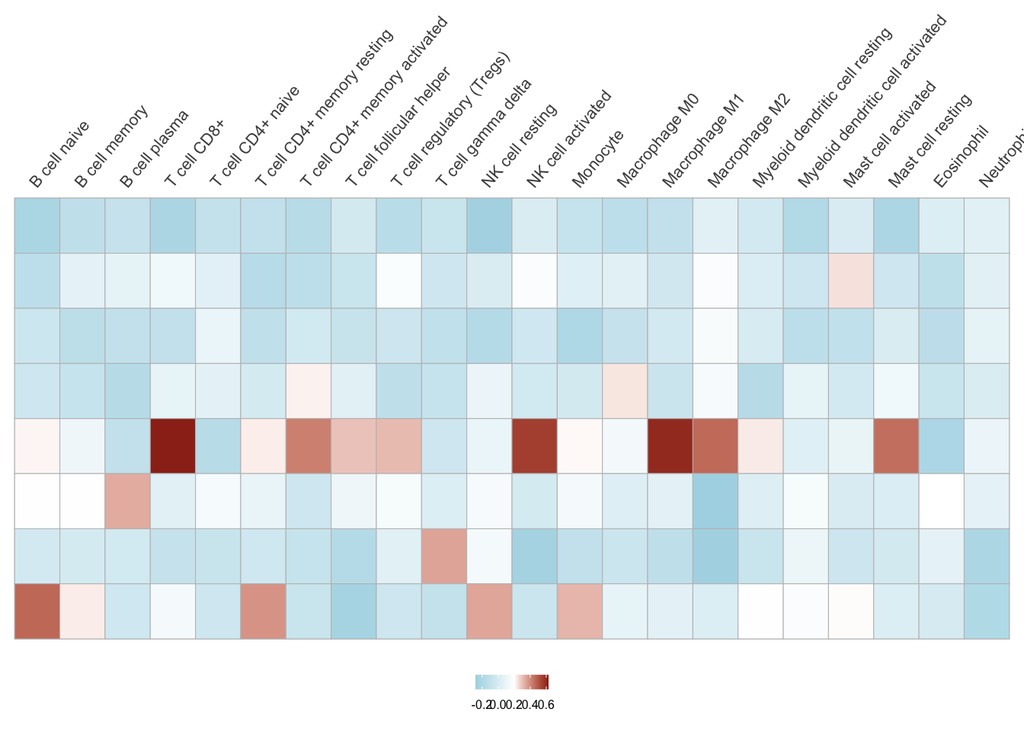

```r
immune.trim <- get_cibersort_correlation( file.path(data.dir,"/results/LBR.cibersort.txt"),
                                          H_matrix_ordered_norm.melt, component_n)

immune.trim <- left_join(immune.trim, y_order.convert, by=c('sig.id'='og'))

immune.trim$cell <- immune.trim$cell.type
immune.trim <- sort_celltypes(immune.trim)

immune.grid <- expand.grid(x = levels(immune.trim$cell.f), y = levels(immune.trim$new))

nmf.cibsersort.plot <-
ggplot(immune.trim, aes(x=cell.type, y=new)) +

  geom_tile(data = immune.grid, aes(x = x, y = y), fill = "white", color = "grey") +
  geom_tile(aes(fill=cor), color = "grey") +

  theme_bw(base_size = base_font_size)+
  guides(size='none',shape='none')+

  theme(axis.text.x = element_text(angle = x_top_angle, hjust = 0),
        panel.grid = element_blank(),
        axis.title = element_blank(),
        axis.ticks = element_blank(),
        axis.text.y = element_blank(),
        panel.spacing = unit(0, "lines"),
        plot.background = element_blank(),
        panel.border = element_blank(),
        strip.background = element_blank(),
        strip.text = element_text(color = "black"),
        legend.position = 'bottom',
        legend.background = element_blank(),
        legend.text = element_text(size = 6),
        legend.key.size = unit(0.5, "lines"),
        legend.title = element_blank()) +
  guides(color = guide_legend(nrow = 3))+

  scale_x_discrete(position = "top", na.translate = FALSE)+
    scale_fill_gradient2(
      low = "lightblue",
      mid = "white",
      high = "darkred",
      midpoint = 0.2,

      na.value = "darkblue"
    )

nmf.cibsersort.plot
```

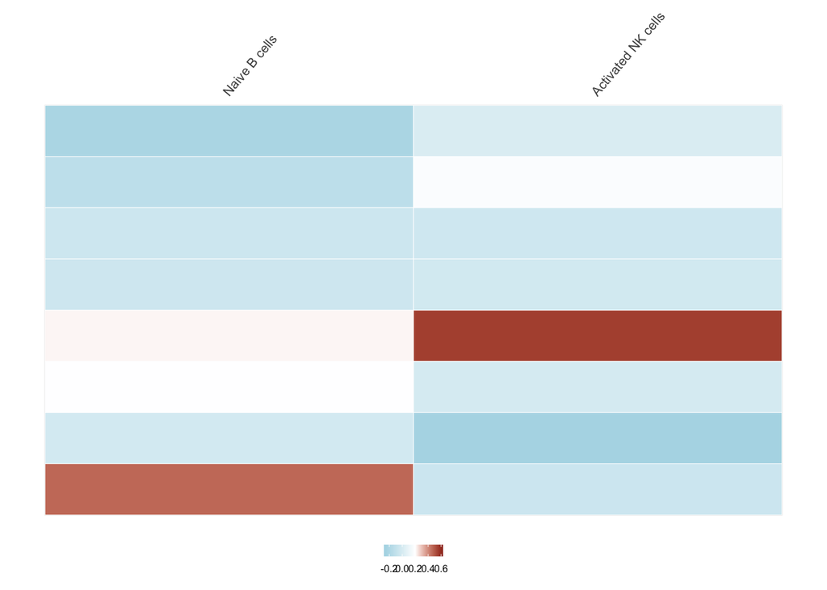

```r
ggsave(file.path(data.dir, "results/fig",paste0(this.cohort,".nmf.cibsersort.svg")),plot =
  nmf.cibsersort.plot
, device = "svg", height = 65, width = 75, units = 'mm',dpi=72 )

## curate
immune.trim$cell <- NA
immune.trim$cell[immune.trim$cell.type == 'B cell naive'] <- 'Naive B cells'
immune.trim$cell[immune.trim$cell.type == 'NK cell activated'] <- 'Activated NK cells'

immune.trim <- sort_celltypes(immune.trim)

immune.grid <- expand.grid(x = levels(immune.trim$cell.f), y = levels(immune.trim$new))

immune.plot <-
ggplot(immune.trim, aes(x=cell.f, y=new)) +

  geom_tile(data = immune.grid, aes(x = x, y = y), fill = "white", color = "grey") +
  geom_tile(aes(fill=cor), color = "white") +

  theme_bw(base_size = base_font_size)+
  guides(size='none',shape='none')+

  theme(axis.text.x = element_text(angle = x_top_angle, hjust = 0),
        panel.grid = element_blank(),
        axis.title = element_blank(),
        axis.ticks = element_blank(),
        axis.text.y = element_blank(),
        panel.spacing = unit(0, "lines"),
        plot.background = element_blank(),
        panel.border = element_blank(),
        strip.background = element_blank(),
        strip.text = element_text(color = "black"),
        legend.position = 'bottom',
        legend.background = element_blank(),
        legend.text = element_text(size = 6),
        legend.key.size = unit(0.5, "lines"),
        legend.title = element_blank()) +
  guides(color = guide_legend(nrow = 3))+

  scale_x_discrete(position = "top", na.translate = FALSE)+
    scale_fill_gradient2(
      low = "lightblue",
      mid = "white",
      high = "darkred",
      midpoint = 0.2,

      na.value = "darkblue"
    )

immune.plot
```

```r
unique_immune <- length(na.omit(unique(immune.trim$cell.f)))
```

## Assemble curated panels

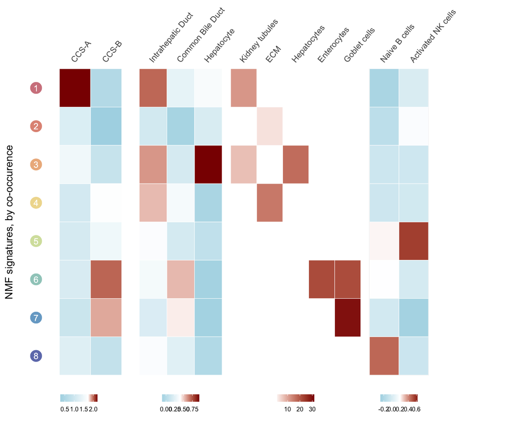

```r
unique_labels = 2 +
  unique_hpa_celltypes +
  unique_sc_celltypes +
  unique_immune

ncol.sum = 4 * 2

gap_width = -0.05
overhead = 0.1

nmf.tissue_match.plot <-
  plot_grid(
     cms.plot, NULL,
     scrna.match.plot , NULL,
     hpa.match.plot , NULL,
     immune.plot , NULL,

     ncol = ncol.sum, align = 'h', axis = "bt",

     rel_widths = c(
       0.25 + (2/unique_labels) + overhead ,                gap_width,
        (unique_sc_celltypes/unique_labels) + overhead,     gap_width / 2,
       (unique_hpa_celltypes/unique_labels) + overhead,   gap_width / 2,
       (unique_immune/unique_labels) + overhead, 0.3
     )
   )
nmf.tissue_match.plot
```

```r
ggsave(file.path(data.dir, "results/fig", paste0(this.cohort,".nmf.tissue_match.svg")),plot =
  nmf.tissue_match.plot
, device = "svg", height = 70, width = 85, units = 'mm' )
```

## By site of tissue

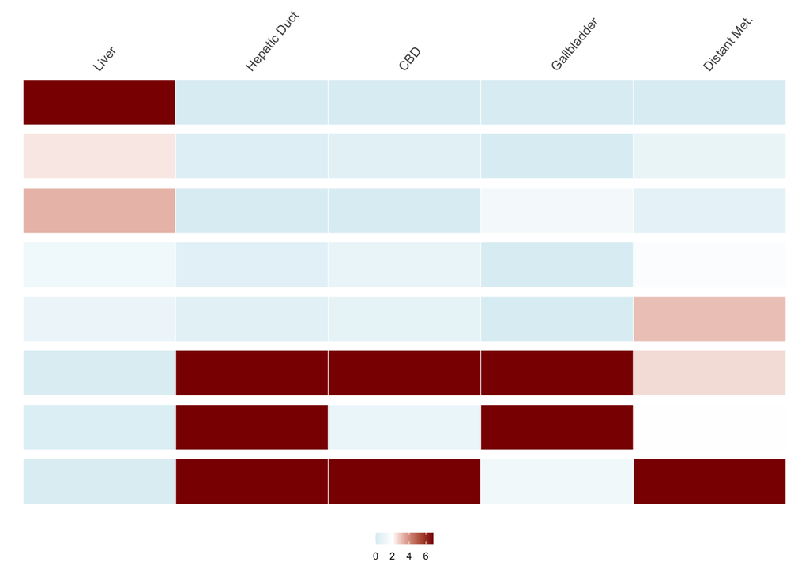

```r
site.info <- fread(file.path(data.dir,"/results/samples.info.txt")) %>%
  dplyr::select(Sample, cellularity, Site_of_tissue, Sample_Progression, location)

site.info$Site_of_tissue[site.info$Site_of_tissue %in% c("Neck","Abdomen","Spine","Lung" )] <- 'Distant Met.'
site.info$Site_of_tissue <- factor(site.info$Site_of_tissue, levels=c("Liver", "Hepatic Duct",  "CBD","Gallbladder", "Distant Met." ))

site.test <- get_tissue_site(site.info, H_matrix_ordered_norm.melt)

site.test <- left_join(site.test, y_order.convert, by=c('sig.id'='og'))
site.test$new.f <- factor(site.test$new, levels=rev(levels(site.test$new)))

site.plot <-
ggplot(site.test, aes(x=site, y=new)) +
  facet_grid(new.f ~ ., scale='free',space='free') +

  geom_tile(aes(fill=effect), color = "white") +

  theme_bw(base_size = base_font_size)+
  guides(size='none',shape='none')+

  theme(axis.text.x = element_text(angle = x_top_angle, hjust = 0),
       # plot.margin = unit(c(0, 10, 0, 1), "mm"),
        panel.grid = element_blank(),
        axis.title = element_blank(),
        axis.ticks = element_blank(),
        axis.text.y = element_blank(),
        panel.spacing = unit(0, "lines"),
        plot.background = element_blank(),
        panel.background = element_blank(),
        panel.border = element_blank(),
        strip.background = element_blank(),
        strip.text =element_blank(),
        legend.position = 'bottom',
        legend.background = element_blank(),
        legend.text = element_text(size = 6),
        legend.key.size = unit(0.5, "lines"),
        legend.title = element_blank()) +

  scale_x_discrete(position = "top", na.translate = FALSE)+
    scale_fill_gradient2(
      low = "lightblue",
      mid = "white",
      high = "darkred",
      na.value = "lightblue",
      midpoint = 2
    )  + coord_cartesian(clip = "off")

site.plot
```

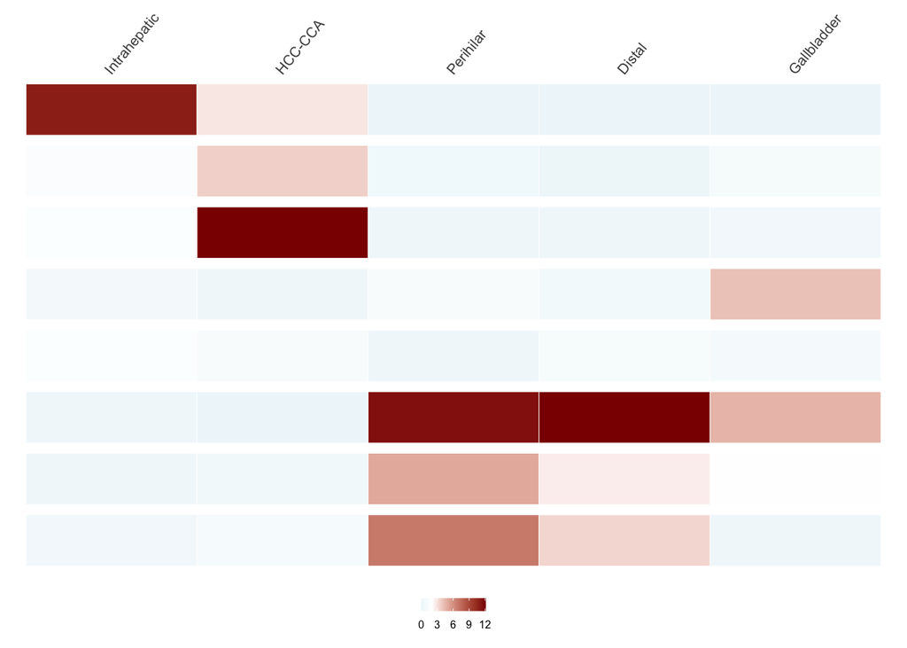

```r
location.info <- site.info
location.info$Site_of_tissue <- location.info$location
location.info$Site_of_tissue <- factor(location.info$Site_of_tissue, levels=c("Intrahepatic","HCC-CCA" , "Perihilar" ,   "Distal"      , "Gallbladder"   ))
location.test <- get_tissue_site(location.info, H_matrix_ordered_norm.melt)

location.test <- left_join(location.test, y_order.convert, by=c('sig.id'='og'))
location.test$new.f <- factor(location.test$new, levels=rev(levels(location.test$new)))

location_plot <-
ggplot(location.test, aes(x=site, y=new)) +
  facet_grid(new.f ~ ., scale='free',space='free') +

  geom_tile(aes(fill=effect), color = "white") +

  theme_bw(base_size = base_font_size)+
  guides(size='none',shape='none')+

  theme(axis.text.x = element_text(angle = x_top_angle, hjust = 0),
       # plot.margin = unit(c(0, 10, 0, 1), "mm"),
        panel.grid = element_blank(),
        axis.title = element_blank(),
        axis.ticks = element_blank(),
        axis.text.y = element_blank(),
        panel.spacing = unit(0, "lines"),
        plot.background = element_blank(),
        panel.background = element_blank(),
        panel.border = element_blank(),
        strip.background = element_blank(),
        strip.text = element_blank(),
        legend.position = 'bottom',
        legend.background = element_blank(),
        legend.text = element_text(size = 6),
        legend.key.size = unit(0.5, "lines"),
        legend.title = element_blank()) +

  scale_x_discrete(position = "top", na.translate = FALSE)+
    scale_fill_gradient2(
      low = "lightblue",
      mid = "white",
      high = "darkred",
      na.value = "lightblue",
      midpoint = 2
    )  + coord_cartesian(clip = "off")
  location_plot
```

```r
predicted.w.score <- fread(file.path(data.dir,'/results/all.eCCS.txt') )
predicted.w.score$rna_class[is.na(predicted.w.score$rna_class) ] <- 'Other'


signature.6 <- H_matrix_ordered_norm.melt

signature.6.info <- left_join(site.info, predicted.w.score) %>%
  left_join(signature.6, by=c('Sample'='variable'))
```

```r
signature.6.info$content.bin <-NA
signature.6.info$content.bin[signature.6.info$cellularity <= 1 ] <- 'High (>=85%)'
signature.6.info$content.bin[signature.6.info$cellularity < 0.85 ] <- 'Mid (65-85%)'
signature.6.info$content.bin[signature.6.info$cellularity <= 0.65 ] <- 'Low (<=65%)'
signature.6.info$Cellularity.f <- factor(signature.6.info$content.bin, levels=c( 'High (>=85%)', 'Mid (65-85%)', 'Low (<=65%)'))
signature.6.info <- left_join(signature.6.info, y_order.convert, by=c('sig.id'='og'))

signature.6.info$rna_class.f <- factor(signature.6.info$rna_class, levels=c(  "Other","CCS-B", "CCS-A"))
signature.6.info$new.f <- factor(signature.6.info$new, levels=rev(levels(signature.6.info$new)))

plot.df <- signature.6.info %>%
  filter(
   # Site_of_tissue == "Liver",
    Sample_Progression == 'Primary',
    !is.na(rna_class),
    !is.na(new),
    rna_class != "Other"
  )

medians <- plot.df %>%
  group_by(new.f, Cellularity.f, rna_class.f) %>%
  summarise(median_val = mean(value, na.rm = TRUE), .groups = "drop")

nmf.liver_primaries <-
ggplot(plot.df, aes(x = value, y = rna_class.f)) +
  facet_grid(new.f ~ Cellularity.f) +
  geom_vline(xintercept = 0) +

# Thick shaft
geom_segment(
  data = medians,
  aes(
    x = 0, xend = median_val * 0.6,
    y = rna_class.f, yend = rna_class.f,
    linewidth = abs(median_val),
    color = rna_class.f
  ),
  lineend = "butt",
  alpha = 0.9
) +

# Arrowhead layer
geom_segment(
  data = medians,
  aes(
    x = median_val * 0.98,
    xend = median_val,
    y = rna_class.f,
        alpha = abs(median_val),

    yend = rna_class.f,
    color = rna_class.f
  ),
  linewidth = 1,
  arrow = arrow(
    type = "closed",
    length = unit(0.25, "cm")
  )
) +
  ggbeeswarm::geom_quasirandom(width = 0.4, alpha = 0.5, shape=21,
                               size=0.8, aes(fill=rna_class.f), color='white') +

  theme_bw() +
  scale_fill_manual(  values=c(
    "CCS-B"    = "#EDA71A" ,
    "CCS-A" = "#04597C" ,
    'Other' ='grey90'
  ), na.value = 'grey90')+
  scale_color_manual(  values=c(
    "CCS-B"    = "#EDA71A" ,
    "CCS-A" = "#04597C" ,
    'Other' ='grey90'
  ), na.value = 'grey90') +
  theme(panel.grid = element_blank(), panel.background = element_blank(), strip.background = element_blank(),
        legend.title = element_blank(), axis.title.y =  element_blank(), axis.text.y = element_blank(),
        axis.ticks.y = element_blank(), plot.background = element_blank()) +
  guides(linewidth='none', color='none', fill='none', alpha='none')+
  labs(x='Normalized Signature Weight', title=' ')



more.signature.variables <-
  plot_grid(
     location_plot, NULL,
     site.plot , NULL,
     nmf.liver_primaries , NULL,

     ncol = 6, align = 'h', axis = "bt",

     rel_widths = c(0.2,0,0.2,0,0.6,0

     )
   )
```

```
## Orientation inferred to be along y-axis; override with
## `position_quasirandom(orientation = 'x')`
```

```r
ggsave(file.path(data.dir, "results/fig", paste0(this.cohort,".more.signature.variables.svg")),plot =
  more.signature.variables
, device = "svg", height = 100, width = 150, units = 'mm' )
```

```r
rna.htseq.all <- fread(file.path(data.dir,"/results/rna.htseq.all.txt"))

replicates.write <- fread(file.path(data.dir,'results', 'replicates.txt'))

rna.htseq.dup <- rna.htseq.all %>% dplyr::select(all_of(c('gene_name',replicates.write$Sample)))

convert_to_nmf_input <- function(joined_file_filt, gene_set, MIN_READ = 0){

  protein_genes <- gene_set$gene_name[gene_set$biotype=="protein_coding" &
                                      gene_set$Length >= 500 &
                                      gene_set$Chr %in% c(1:23)]

  joined_file_protein <- joined_file_filt %>%
    filter(gene_name %in% protein_genes)

  genes <- joined_file_protein$gene_name
  btc_tpm <- as.matrix(joined_file_protein[,-1])
  rownames(btc_tpm) <- genes

  min_samples <- round(0.50*ncol(btc_tpm))

  btc_tpm_filtered <- btc_tpm[rowSums(btc_tpm > MIN_READ) >= min_samples,]

  btc_tpm_filtered <- log(btc_tpm_filtered + 1)
  return(btc_tpm_filtered)
}

rna.htseq.norm <- convert_to_nmf_input(rna.htseq.dup, gene_set)
rna.htseq.df <- cbind.data.frame('gene_name'=rownames(rna.htseq.norm),rna.htseq.norm)
rna.htseq.df <- left_join(gene_set, rna.htseq.df)
rna.htseq.df$ensid <- factor(rna.htseq.df$ensid, levels = rownames(W_matrix))
rna.htseq.filt <- rna.htseq.df %>% filter(!is.na(ensid)) %>% arrange(ensid)
rna.htseq.filt[is.na(rna.htseq.filt)] <- 0
rna.htseq.mat <- as.matrix(rna.htseq.filt[,-c(1:9)])

rna.sigs <- t(as.matrix(W_matrix)) %*% rna.htseq.mat
h.scaled <- data.frame(t(apply(rna.sigs, 1, scale)))
names(h.scaled) <- colnames(rna.sigs)
h.scaled$sig.id <- paste0('sig',c(1:nrow(h.scaled)))
h.scaled.melt <- melt(h.scaled)
```

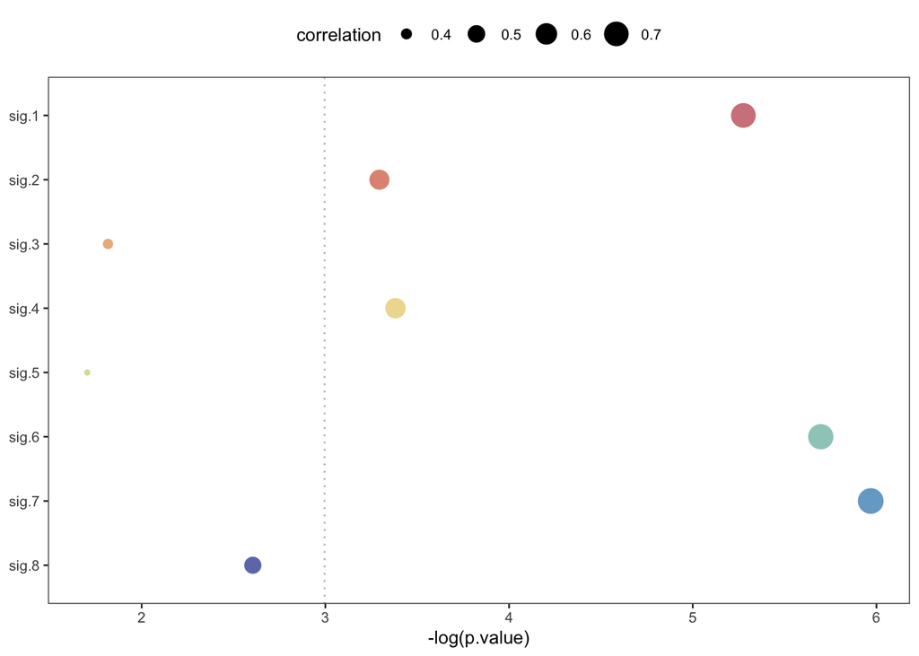

```r
names(h.scaled.melt)[3] <- 'new.value'

h.scaled.dup <- left_join(
  h.scaled.melt,
  replicates.write %>% dplyr::select(BTC_ID, Sample, curated, cellularity) ,
  by=c('variable'='Sample'))

h.scaled.dup$curated[h.scaled.dup$curated == 'TRUE'] <- 'curated'

color.set <-    pnw_palette(name="Sailboat", n=8 )
names(color.set) <- paste0('sig.',c(8:1))

h.scaled.dcast <- dcast(h.scaled.dup, BTC_ID + sig.id ~ curated, value.var = 'new.value')
h.scaled.dcast <- left_join(h.scaled.dcast, y_order.convert, by=c('sig.id'='og'))

repeat.correlation = NULL
for(this.sig in rev(sort(unique(h.scaled.dcast$new)))){

  cor.res <- cor.test(x = h.scaled.dcast$replicate[h.scaled.dcast$new == this.sig],
         y = h.scaled.dcast$curated[h.scaled.dcast$new == this.sig])

 this.correlation <-  cbind.data.frame(
    sig = this.sig,
    estimate = cor.res$estimate,
    p.value = cor.res$p.value
  )

 if(is.null(repeat.correlation)){ repeat.correlation <-this.correlation } else {
   repeat.correlation <-rbind.data.frame(repeat.correlation, this.correlation)
 }

}

repeat.correlation$new <- factor(repeat.correlation$sig, levels=paste0('sig.',c(8:1)))

replicate.nmf.plot <-
ggplot(repeat.correlation,aes( x=-log(p.value), y=new))+
  geom_vline(xintercept = -log(0.05), color='grey',linetype='dotted')+
  geom_point(aes(size=estimate, color=new))+
  scale_color_manual(values =   color.set, na.value = 'white') +
  theme_bw(base_size=10) +
  theme(panel.grid = element_blank(),
        legend.position = 'top',
        plot.background = element_blank(),
        panel.background = element_blank(),
        axis.title.y = element_blank(),
        strip.background = element_blank()) +
  guides(color='none') +
  labs(size='correlation')

replicate.nmf.plot
```

```r
ggsave(file.path(data.dir, "results/fig", 'figs3f.replicate.nmf.plot.svg'),plot =
  replicate.nmf.plot
, device = "svg", height = 80, width = 40, units = 'mm' )
```